# Calculation of Timothy and Watergrass seed abundance.Summer 2020

Emilio A. Laca

2021-10-15

## 0.1 Names of variables

Whenever a different name is encountered for these variables, it will be corrected accordingly.

1. Refuge (for spelled-out refuge names, do not use as a key field)
2. LIT (use as the key field)
3. Unit_Name
4. Subunit_Name
5. subunit_ID (paste(LIT, Unit_Name, Subunit_Name, sep = "_"))
6. group (paste(LIT, Unit_Name, Subunit_Name, Stratum, sep = "_"))
7. Stratum (“a.Low”, “b.Med”, “c.High”)
8. LIT_Strat (factor(paste(LIT, Stratum, sep = "_")))

## 0.2 Read RDS’s

## 0.3 Models to go from seed dimensions to mass

## 0.4 Prepare utility info

## 0.5 Read data files

```
## 'data.frame':    349 obs. of  10 variables:
##  $ LIT           : chr  "KRN" "KRN" "KRN" "KRN" ...
##  $ Unit_Name     : chr  "4A" "4A" "4A" "4A" ...
##  $ Subunit_Name  : chr  "4A-1" "4A-1" "4A-1" "4A-1" ...
##  $ Stratum       : Factor w/ 3 levels "a.Low","b.Med",..: 1 1 1 2 3 3 1 1 2 3 ...
##  $ avg_length_mm : num  8.2 8 6.4 12.6 10.4 8 11.2 11.8 11.8 12.2 ...
##  $ n_seed_head_m2: num  2222.2 8400 44.4 2133.3 18800 ...
##  $ no_sh         : num  2222.2 8400 44.4 2133.3 18800 ...
##  $ mass_g_m2     : num  24.65 89.546 0.306 52.532 327.417 ...
##  $ subunit_ID    : chr  "KRN_4A_4A-1" "KRN_4A_4A-1" "KRN_4A_4A-1" "KRN_4A_4A-1" ...
##  $ LIT_Strat     : Factor w/ 12 levels "KRN_a.Low","KRN_b.Med",..: 1 1 1 2 3 3 1 1 2 3 ...
```

```
## 'data.frame':    125 obs. of  10 variables:
##  $ LIT           : chr  "MDC" "MDC" "MDC" "MDC" ...
##  $ Unit_Name     : chr  "Gadwall" "Gadwall" "Grandma Tract 10" "Grandma Tract 10" ...
##  $ Subunit_Name  : chr  "Gadwall" "Gadwall" "Grandma Tract 10" "Grandma Tract 10" ...
##  $ Stratum       : Factor w/ 3 levels "a.Low","b.Med",..: 1 2 1 1 2 2 1 1 1 2 ...
##  $ avg_length_mm : num  48 67 43.2 25.6 20.4 ...
##  $ n_seed_head_m2: num  40 50 70 80 220 320 30 10 100 60 ...
##  $ sh_mass_mg    : num  37.9 63.1 40.1 22.5 16.5 ...
##  $ mass_g_m2     : num  1.51 3.15 2.81 1.8 3.62 ...
##  $ subunit_ID    : chr  "MDC_Gadwall_Gadwall" "MDC_Gadwall_Gadwall" "MDC_Grandma Tract 10_Grandma Tract 10" "MDC_Grandma Tract 10_Grandma Tract 10" ...
##  $ LIT_Strat     : Factor w/ 8 levels "MDC_a.Low","MDC_b.Med",..: 1 2 1 1 2 2 1 1 1 2 ...
```

## 0.6 Area per subunit

## 0.7 Estimation of proportions of areas

Proportion of areas

See http://www.analyticalgroup.com/download/WEIGHTED_MEAN.pdf for var(weighted average) and AREA FRAME DESIGN.pdf

## 0.8 Function to estimate mass per unit area in each stratum

```
##      Stratum
## LIT   a.Low b.Med c.High
##   MDC    46    22     25
##   PIX    16     6      6
##   SLW     3     0      1
```

Make a data frame with the seed mass per unit area for each stratum, and species (columns) for each subunit (rows). `seed_mass_fun` is a function that takes the file `p_Area`, and the models for g.m2 by Subunit_Name and Stratum (“st_rlm3” and “wg_rlm3”) as arguments and yields the seed mass of st and wg per unit area of each subunit, and the area of each subunit. The resulting file can be used to calculate refuge-level yields.

## 0.9 Mass per subunit and refuge

### 0.9.1 Mass per subunit is given as average g/m2 over the whole subunit area.

```
## tibble [65 × 14] (S3: tbl_df/tbl/data.frame)
##  $ LIT           : chr [1:65] "KRN" "KRN" "KRN" "KRN" ...
##  $ Unit_Name     : chr [1:65] "4A" "4A" "4A" "4A" ...
##  $ Subunit_Name  : chr [1:65] "4A-1" "4A-2" "4A-3" "4A-4" ...
##  $ subunit_ID    : chr [1:65] "KRN_4A_4A-1" "KRN_4A_4A-2" "KRN_4A_4A-3" "KRN_4A_4A-4" ...
##  $ st_g_m2_a.Low : num [1:65] 18 18 18 18 18 ...
##  $ st_g_m2_b.Med : num [1:65] 103 103 103 103 103 ...
##  $ st_g_m2_c.High: num [1:65] 293 293 293 293 293 ...
##  $ wg_g_m2_a.Low : num [1:65] 0 0 0 0 0 0 0 0 0 0 ...
##  $ wg_g_m2_b.Med : num [1:65] 0 0 0 0 0 0 0 0 0 0 ...
##  $ wg_g_m2_c.High: num [1:65] 0 0 0 0 0 0 0 0 0 0 ...
##  $ wg_g_m2       : num [1:65] 0 0 0 0 0 0 0 0 0 0 ...
##  $ st_g_m2       : num [1:65] 67.8 80.4 260.2 135.2 174.9 ...
##  $ tot_g_m2      : num [1:65] 67.8 80.4 260.2 135.2 174.9 ...
##  $ area_ha       : num [1:65] 19.48 17.46 8.98 20.62 21.95 ...
##  - attr(*, "na.action")= 'omit' Named int [1:18] 66 67 68 69 70 71 72 73 74 75 ...
##   ..- attr(*, "names")= chr [1:18] "66" "67" "68" "69" ...
##  - attr(*, "notes")= chr "These estimations exclude the uncertainty due to the proportion of area covered by each stratum in each unit, a"| __truncated__
```

Average seed mass per subunit area. Total mass of seed estimated for the subunit divided by the total area of the subunit. These estimations exclude the uncertainty due to the proportion of area covered by each stratum in each unit, and the uncertainty of the model to convert seed number and seed length into mass.

| LIT | Unit_Name | Subunit_Name | wg_g_m2 | st_g_m2 | tot_g_m2 | area_ha |
| --- | --- | --- | --- | --- | --- | --- |
| KRN | 4A | 4A-1 | 0.0 | 67.8 | 67.8 | 19.5 |
| KRN | 4A | 4A-2 | 0.0 | 80.4 | 80.4 | 17.5 |
| KRN | 4A | 4A-3 | 0.0 | 260.2 | 260.2 | 9.0 |
| KRN | 4A | 4A-4 | 0.0 | 135.2 | 135.2 | 20.6 |
| KRN | 4A | 4A-5 | 0.0 | 174.9 | 174.9 | 22.0 |
| KRN | 4A | 4A-6 | 0.0 | 80.2 | 80.2 | 26.7 |
| KRN | 4B | 4B-1 | 0.0 | 93.4 | 93.4 | 25.9 |
| KRN | 4B | 4B-2 | 0.0 | 66.6 | 66.6 | 17.7 |
| KRN | 4B | 4B-3 | 0.0 | 241.8 | 241.8 | 19.0 |
| KRN | 5A | 5A-1 | 0.0 | 146.1 | 146.1 | 18.7 |
| KRN | 5A | 5A-3 | 0.0 | 60.1 | 60.1 | 21.2 |
| KRN | 5A | 5A-4 | 0.0 | 100.0 | 100.0 | 18.9 |
| KRN | 5A | 5A-6 | 0.0 | 163.3 | 163.3 | 14.1 |
| KRN | 5A | 5A-7 | 0.0 | 105.7 | 105.7 | 19.6 |
| KRN | 5B | 5B-1 | 0.0 | 143.0 | 143.0 | 9.2 |
| KRN | 5B | 5B-2 | 0.0 | 54.1 | 54.1 | 11.9 |
| KRN | 5B | 5B-3 | 0.0 | 106.1 | 106.1 | 23.3 |
| KRN | 5B | 5B-5 | 0.0 | 20.8 | 20.8 | 20.3 |
| KRN | 5B | 5B-6 | 0.0 | 83.8 | 83.8 | 13.0 |
| KRN | 5B | 5B-7 | 0.0 | 189.6 | 189.6 | 12.1 |
| KRN | 5B | 5B-8 | 0.0 | 112.2 | 112.2 | 19.4 |
| KRN | 6A | 6A-1 | 0.0 | 61.7 | 61.7 | 21.8 |
| KRN | 6A | 6A-2 | 0.0 | 42.0 | 42.0 | 20.2 |
| KRN | 6A | 6A-4 | 0.0 | 77.1 | 77.1 | 11.5 |
| KRN | 6A | 6A-5 | 0.0 | 85.7 | 85.7 | 13.8 |
| MDC | Duck Ponds | Duck Ponds | 0.0 | 121.4 | 121.4 | 71.7 |
| MDC | Flournoy Pond | Flournoy Pond | 0.0 | 63.7 | 63.7 | 21.7 |
| MDC | Gadwall | Gadwall | 0.9 | 44.5 | 45.4 | 26.0 |
| MDC | Grandma Tract 10 | Grandma Tract 10 | 1.1 | 0.0 | 1.1 | 14.0 |
| MDC | Grandma Tract 11 | Grandma Tract 11 | 0.0 | 0.0 | 0.0 | 6.1 |
| MDC | Grandma Tract 2 | Grandma Tract 2 | 3.3 | 17.0 | 20.4 | 8.5 |
| MDC | Grandma Tract 3 | Grandma Tract 3 | 10.7 | 0.0 | 10.7 | 12.5 |
| MDC | Grandma Tract 4 | Grandma Tract 4 | 2.4 | 0.0 | 2.4 | 11.9 |
| MDC | Grandma Tract 7 | Grandma Tract 7 | 0.0 | 0.0 | 0.0 | 14.3 |
| MDC | Grandma Tract 8 | Grandma Tract 8 | 1.8 | 0.0 | 1.8 | 11.2 |
| MDC | Grandma Tract 9 | Grandma Tract 9 | 3.8 | 0.0 | 3.8 | 11.2 |
| MDC | House Field | House Field | 0.0 | 123.8 | 123.8 | 25.4 |
| MDC | J Pond | J Pond | 7.8 | 8.6 | 16.4 | 22.8 |
| MDC | Matney 3 | Matney 3 | 0.0 | 72.2 | 72.2 | 12.0 |
| MDC | Matney 4 North | Matney 4 North | 2.1 | 73.7 | 75.8 | 8.3 |
| MDC | Matney 4 South | Matney 4 South | 4.5 | 52.7 | 57.2 | 7.6 |
| MDC | Matney 6 | Matney 6 | 2.4 | 80.8 | 83.2 | 9.4 |
| MDC | Matney 7 | Matney 7 | 0.0 | 0.0 | 0.0 | 10.1 |
| MDC | Matney 8 | Matney 8 | 9.6 | 14.7 | 24.3 | 12.6 |
| MDC | South Dam Pond | South Dam Pond | 0.0 | 49.9 | 49.9 | 8.5 |
| MDC | Upper Goose Pond | Upper Goose Pond | 0.0 | 93.6 | 93.6 | 21.2 |
| PIX | 1 | 1 | 0.0 | 66.0 | 66.0 | 57.1 |
| PIX | 2 | 2 | 2.2 | 264.4 | 266.6 | 20.1 |
| PIX | 2A | 2A | 0.2 | 179.3 | 179.5 | 22.4 |
| PIX | 3 | 3 | 9.3 | 247.0 | 256.3 | 19.6 |
| PIX | 3A | 3A | 7.9 | 235.2 | 243.1 | 30.0 |
| PIX | 4 | 4 | 6.2 | 196.8 | 203.1 | 18.1 |
| PIX | 4A | 4A | 1.5 | 94.6 | 96.1 | 18.3 |
| PIX | 6 | 6 | 0.0 | 48.0 | 48.0 | 46.3 |
| PIX | 7A | 7A | 0.0 | 248.7 | 248.7 | 12.7 |
| PIX | 7B | 7B | 133.7 | 8.0 | 141.6 | 12.2 |
| PIX | 8A | 8A | 0.0 | 89.1 | 89.1 | 11.6 |
| PIX | 8B | 8B | 0.5 | 257.7 | 258.2 | 17.8 |
| PIX | 9A | 9A | 8.7 | 229.2 | 237.9 | 12.4 |
| PIX | 9B | 9B | 1.3 | 222.5 | 223.8 | 13.5 |
| SLW | Beach Lake 1 | Beach Lake 1 | 0.0 | 6.0 | 6.0 | 16.5 |
| SLW | Beach Lake 3 | Beach Lake 3 | 0.0 | 76.2 | 76.2 | 7.3 |
| SLW | Lewis 1 | 22 | 3.6 | 11.2 | 14.8 | 12.0 |
| SLW | Lewis 6 | 22 | 10.9 | 6.2 | 17.1 | 23.7 |
| SLW | LIC | 57 | 1.8 | 68.6 | 70.4 | 28.7 |

### 0.9.2 Calculate mass per refuge (kg) based on original sample.

Total seed mass in each refuge, areas and seed mass per unit area. These estimations exclude the uncertainty due to the proportion of area covered by each stratum in each unit, and the uncertainty of the model to convert seed number and seed length into mass.

| LIT | mass_kg_lit | tot_ha | kg.ha |
| --- | --- | --- | --- |
| KRN | 469621 | 447 | 1051 |
| MDC | 206416 | 347 | 595 |
| PIX | 495800 | 312 | 1589 |
| SLW | 32587 | 88 | 370 |

## 0.10 Mass estimates and distributions with quadrat variance.

Seed yield, confidence intervals. etc. for each subunit and refuge are calculated by resampling yield per stratum for each subunit.

Using `tidymodels` and `rsample`.

```
##    user  system elapsed
##  94.815   0.467  95.435
```

Create matrix of bootstrap estimates to calculate variances and covariances.

```
## # A tibble: 153,090 × 4
##    id            wg_g_m2 st_g_m2 tot_g_m2
##    <chr>           <dbl>   <dbl>    <dbl>
##  1 Bootstrap0002       0    60.6     60.6
##  2 Bootstrap0002       0    70.6     70.6
##  3 Bootstrap0002       0   227.     227.
##  4 Bootstrap0002       0   119.     119.
##  5 Bootstrap0002       0   153.     153.
##  6 Bootstrap0002       0    71.2     71.2
##  7 Bootstrap0002       0    82.7     82.7
##  8 Bootstrap0002       0    59.0     59.0
##  9 Bootstrap0002       0   211.     211.
## 10 Bootstrap0002       0   129.     129.
## # … with 153,080 more rows
```

```
## # A tibble: 65 × 10
##    subunit_ID         wg_q10  wg_mean  wg_q90   st_q10  st_mean   st_q90 tot_q10
##    <chr>               <dbl>    <dbl>   <dbl>    <dbl>    <dbl>    <dbl>   <dbl>
##  1 KRN_4A_4A-1        0        0      0        63.4     6.79e+1  7.26e+1   63.4
##  2 KRN_4A_4A-2        0        0      0        74.7     8.04e+1  8.67e+1   74.7
##  3 KRN_4A_4A-3        0        0      0       240.      2.60e+2  2.82e+2  240.
##  4 KRN_4A_4A-4        0        0      0       126.      1.35e+2  1.45e+2  126.
##  5 KRN_4A_4A-5        0        0      0       162.      1.75e+2  1.89e+2  162.
##  6 KRN_4A_4A-6        0        0      0        74.9     8.02e+1  8.56e+1   74.9
##  7 KRN_4B_4B-1        0        0      0        87.2     9.35e+1  1.00e+2   87.2
##  8 KRN_4B_4B-2        0        0      0        62.0     6.67e+1  7.12e+1   62.0
##  9 KRN_4B_4B-3        0        0      0       225.      2.42e+2  2.60e+2  225.
## 10 KRN_5A_5A-1        0        0      0       136.      1.46e+2  1.56e+2  136.
## 11 KRN_5A_5A-3        0        0      0        56.0     6.02e+1  6.47e+1   56.0
## 12 KRN_5A_5A-4        0        0      0        92.9     1.00e+2  1.08e+2   92.9
```

[output cut: 54 more lines]

## 0.11 Mass estimates with quadrat and area variance

### 0.11.1 Sum of products of independent variables

The formula used is:

$$\sigma^2_{\sum(X_i Y_i)} = \sum{\left((\sigma^2_{X_i} + \mu^2_{X_i})(\sigma^2_{Y_i} + \mu^2_{Y_i}) - \mu^2_{X_i} \mu^2_{Y_i}\right)}$$

where $X_i$ are the values of mass per unit are for each stratum and the $Y_i$ are the proportions of each stratum in the subunit. The variances of $X_i$ are obtained from the bootstrapped data and the variances of $Y_i$ are given by the calculation of `v_Area_c`.

```
## # A tibble: 65 × 9
##    LIT   Unit_Name      Subunit_Name   wg_g_m2  st_g_m2 CI80lwr tot_g_m2 CI80upr
##    <chr> <chr>          <chr>            <dbl>    <dbl>   <dbl>    <dbl>   <dbl>
##  1 KRN   5A             5A-1           0       146.     130.      146.    162.
##  2 KRN   6A             6A-4           0        77.1     68.5      77.1    85.7
##  3 PIX   9B             9B             1.31e+0 223.     200.      224.    248.
##  4 KRN   4B             4B-1           0        93.4     81.8      93.4   105.
##  5 KRN   5A             5A-6           0       163.     143.      163.    183.
##  6 KRN   5B             5B-7           0       190.     167.      190.    212.
##  7 PIX   4              4              6.24e+0 197.     178.      203.    228.
##  8 PIX   8B             8B             4.81e-1 258.     228.      258.    288.
##  9 KRN   4A             4A-4           0       135.     117.      135.    153.
## 10 KRN   4B             4B-3           0       242.     210.      242.    274.
## 11 PIX   2A             2A             1.74e-1 179.     156.      180.    203.
## 12 PIX   3A             3A             7.91e+0 235.     212.      243.    274.
```

[output cut: 54 more lines]

## 0.12 Graphical display of results =======

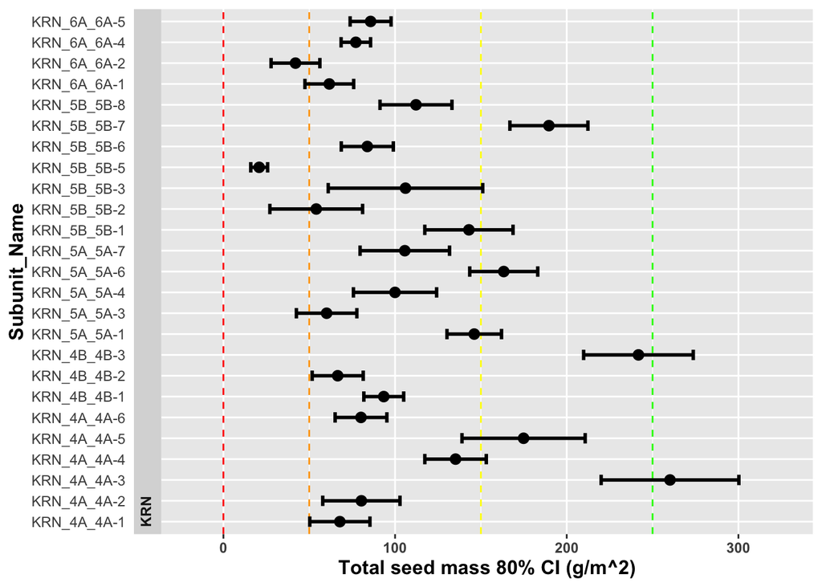

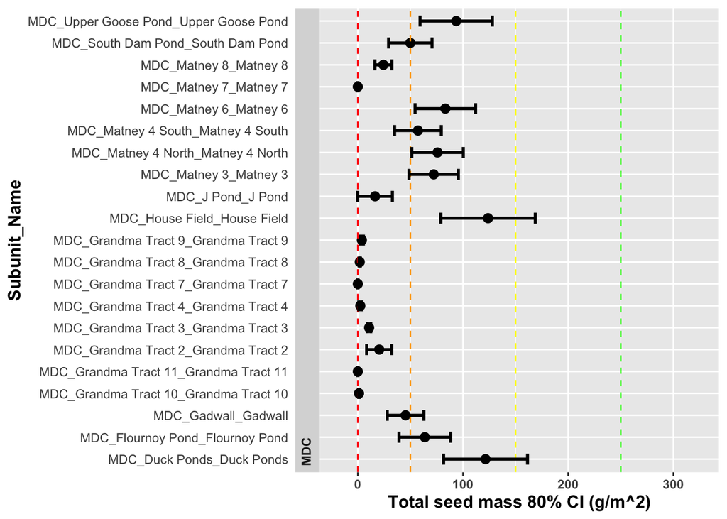

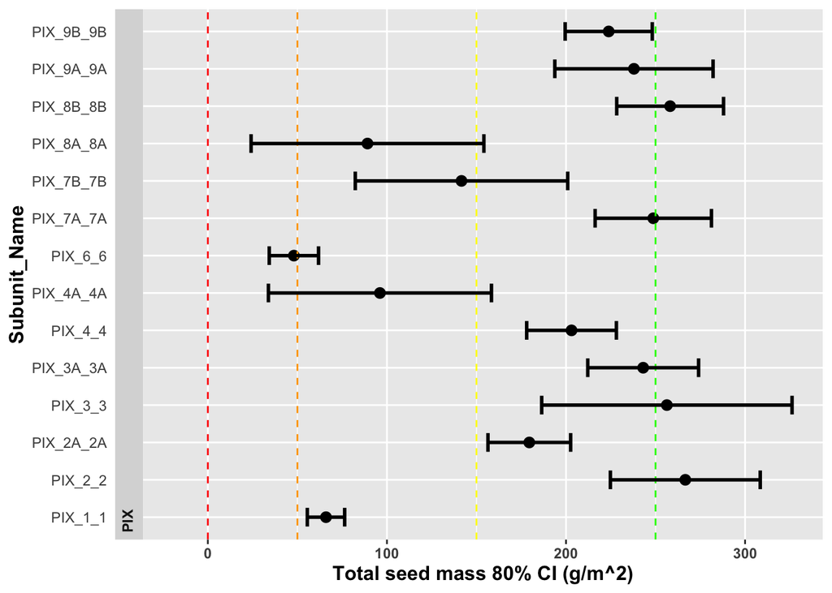

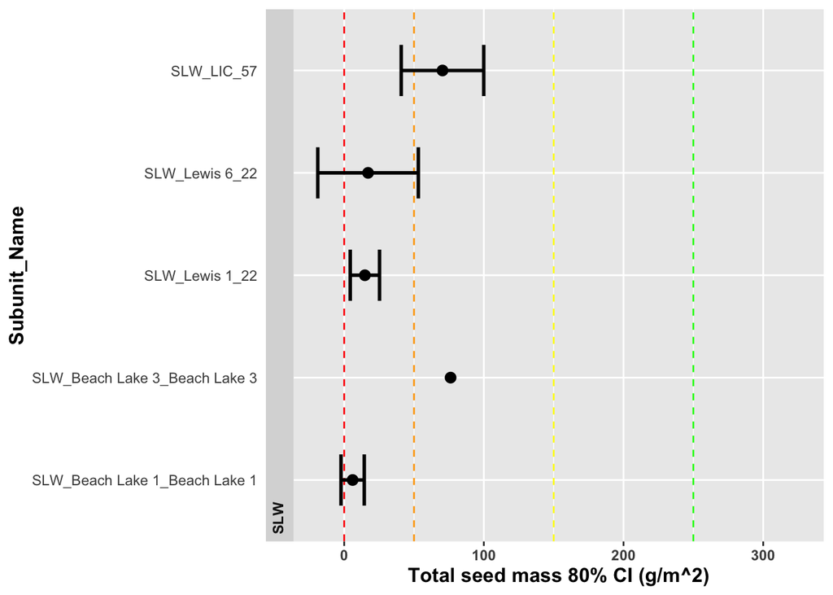

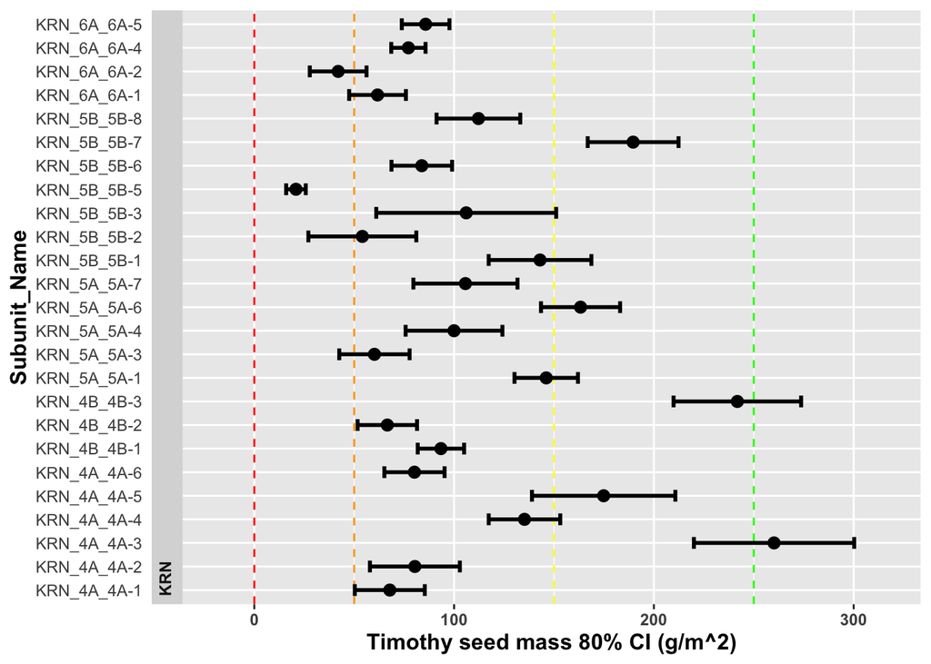

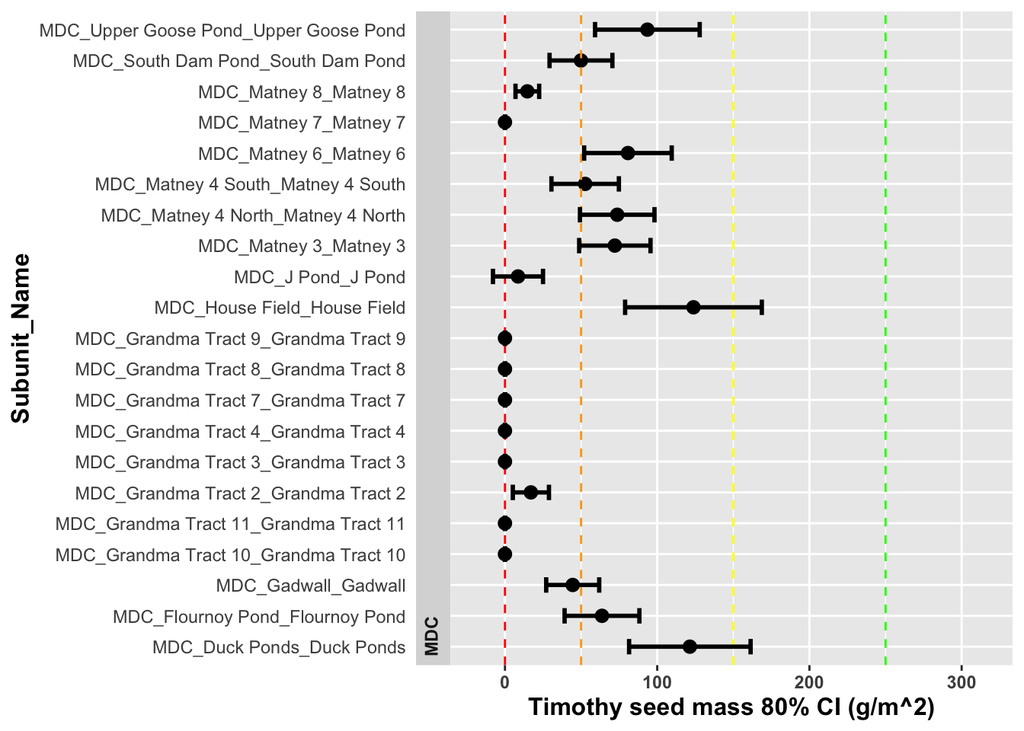

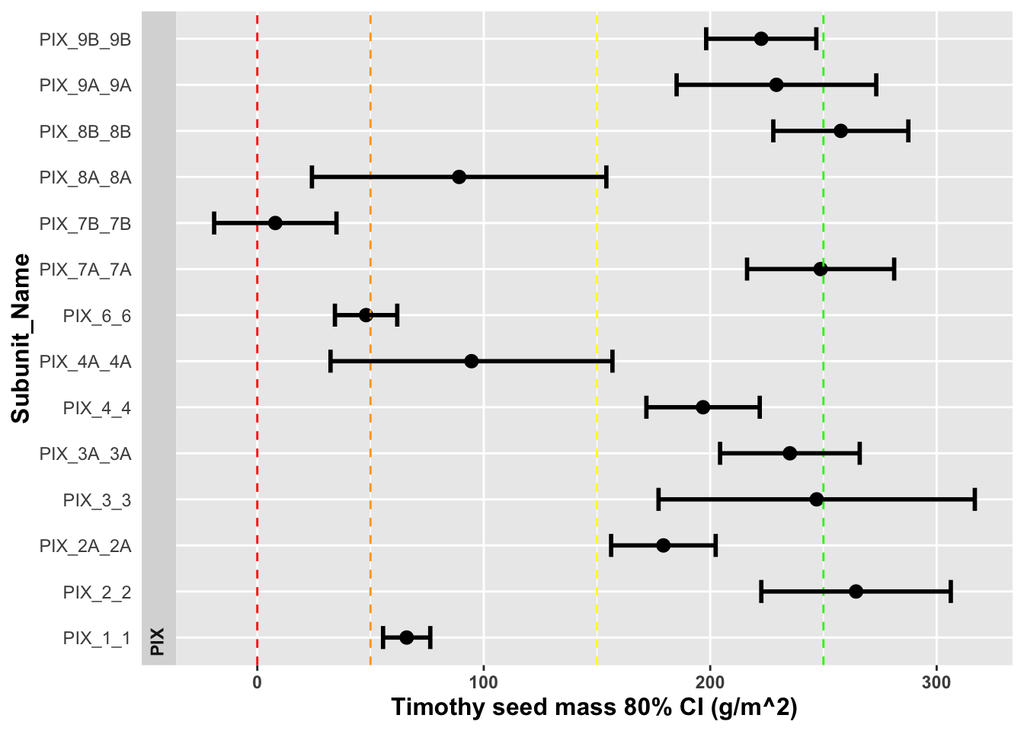

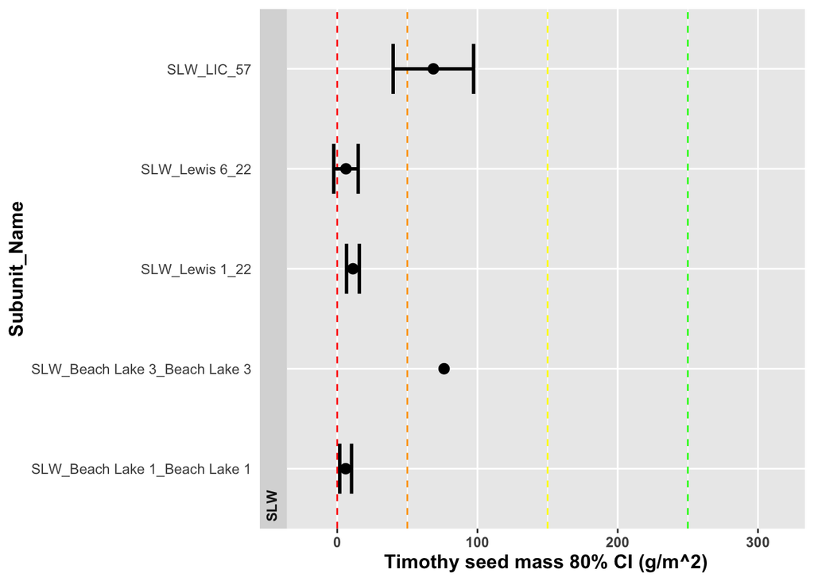

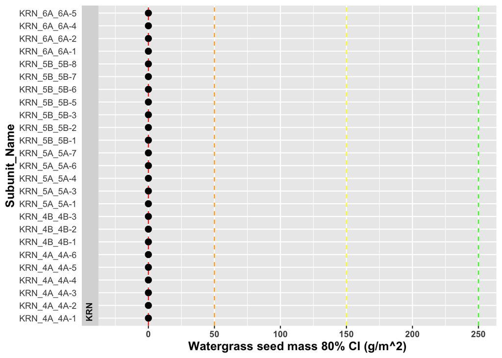

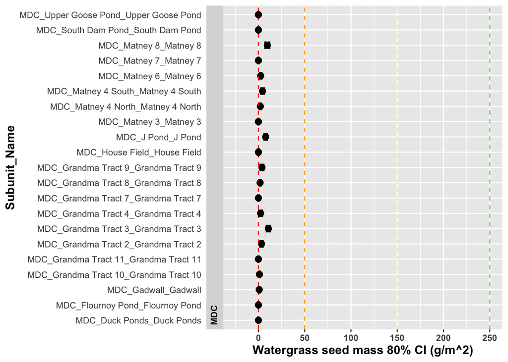

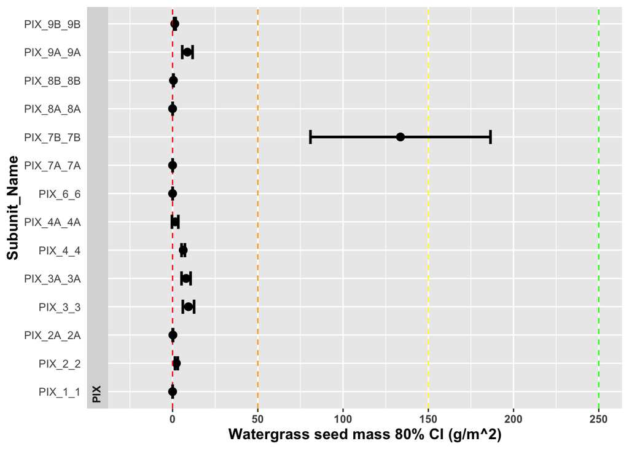

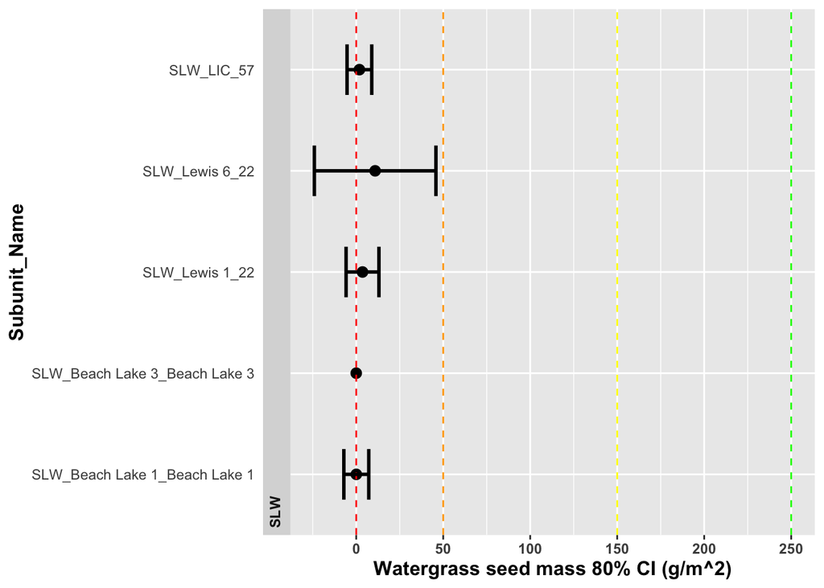

## 0.13 Test of differences in mass/m.sq among units within refuge

```
## # A tibble: 300 × 4
##     diff.name                   mean.a mean.b approx_p_value
##     <chr>                        <dbl>  <dbl>          <dbl>
##   1 KRN_4A_4A-2 vs. KRN_4A_4A-1   80.4   67.8    0.287
##   2 KRN_4A_4A-3 vs. KRN_4A_4A-1  260.    67.8    0.000000009
##   3 KRN_4A_4A-4 vs. KRN_4A_4A-1  135.    67.8    0.000282
##   4 KRN_4A_4A-5 vs. KRN_4A_4A-1  175.    67.8    0.000296
##   5 KRN_4A_4A-6 vs. KRN_4A_4A-1   80.2   67.8    0.247
##   6 KRN_4B_4B-1 vs. KRN_4A_4A-1   93.4   67.8    0.0594
##   7 KRN_4B_4B-2 vs. KRN_4A_4A-1   66.6   67.8    0.472
##   8 KRN_4B_4B-3 vs. KRN_4A_4A-1  242.    67.8    0
##   9 KRN_5A_5A-1 vs. KRN_4A_4A-1  146.    67.8    0.0000111
##  10 KRN_5A_5A-3 vs. KRN_4A_4A-1   60.1   67.8    0.345
##  11 KRN_5A_5A-4 vs. KRN_4A_4A-1  100.    67.8    0.0842
##  12 KRN_5A_5A-6 vs. KRN_4A_4A-1  163.    67.8    0.00000185
```

[output cut: 608 more lines]

Proportion of area in each stratum by subunit

| subunit_ID | p_wg_a.Low | p_wg_b.Med | p_wg_c.High | p_st_a.Low | p_st_b.Med | p_st_c.High | p_noFood |
| --- | --- | --- | --- | --- | --- | --- | --- |
| KRN_4A_4A-1 | 0.000 | 0.000 | 0.000 | 0.253 | 0.079 | 0.188 | 0.480 |
| KRN_4A_4A-2 | 0.037 | 0.000 | 0.312 | 0.094 | 0.032 | 0.257 | 0.268 |
| KRN_4A_4A-3 | 0.000 | 0.000 | 0.000 | 0.000 | 0.000 | 0.888 | 0.112 |
| KRN_4A_4A-4 | 0.000 | 0.000 | 0.000 | 0.200 | 0.151 | 0.396 | 0.253 |
| KRN_4A_4A-5 | 0.000 | 0.000 | 0.000 | 0.137 | 0.060 | 0.567 | 0.236 |
| KRN_4A_4A-6 | 0.000 | 0.000 | 0.000 | 0.168 | 0.169 | 0.204 | 0.459 |
| KRN_4B_4B-1 | 0.000 | 0.000 | 0.000 | 0.183 | 0.134 | 0.261 | 0.423 |
| KRN_4B_4B-2 | 0.000 | 0.000 | 0.000 | 0.082 | 0.212 | 0.148 | 0.558 |
| KRN_4B_4B-3 | 0.000 | 0.000 | 0.000 | 0.000 | 0.216 | 0.749 | 0.035 |
| KRN_5A_5A-1 | 0.000 | 0.000 | 0.000 | 0.197 | 0.322 | 0.374 | 0.107 |
| KRN_5A_5A-3 | 0.000 | 0.000 | 0.000 | 0.079 | 0.050 | 0.183 | 0.688 |
| KRN_5A_5A-4 | 0.000 | 0.000 | 0.000 | 0.113 | 0.055 | 0.315 | 0.517 |
| KRN_5A_5A-6 | 0.000 | 0.000 | 0.000 | 0.129 | 0.273 | 0.453 | 0.144 |
| KRN_5A_5A-7 | 0.000 | 0.000 | 0.002 | 0.198 | 0.096 | 0.315 | 0.389 |
| KRN_5B_5B-1 | 0.000 | 0.000 | 0.000 | 0.148 | 0.099 | 0.444 | 0.309 |
| KRN_5B_5B-2 | 0.000 | 0.000 | 0.000 | 0.245 | 0.196 | 0.101 | 0.458 |
| KRN_5B_5B-3 | 0.000 | 0.000 | 0.000 | 0.050 | 0.070 | 0.334 | 0.545 |
| KRN_5B_5B-5 | 0.000 | 0.000 | 0.000 | 0.135 | 0.084 | 0.034 | 0.748 |
| KRN_5B_5B-6 | 0.000 | 0.000 | 0.000 | 0.299 | 0.198 | 0.198 | 0.305 |
| KRN_5B_5B-7 | 0.000 | 0.000 | 0.000 | 0.160 | 0.210 | 0.564 | 0.066 |
| KRN_5B_5B-8 | 0.000 | 0.000 | 0.000 | 0.249 | 0.299 | 0.263 | 0.190 |
| KRN_6A_6A-1 | 0.000 | 0.000 | 0.000 | 0.281 | 0.180 | 0.130 | 0.409 |
| KRN_6A_6A-2 | 0.000 | 0.000 | 0.000 | 0.348 | 0.000 | 0.122 | 0.530 |
| KRN_6A_6A-4 | 0.000 | 0.000 | 0.000 | 0.199 | 0.148 | 0.199 | 0.454 |
| KRN_6A_6A-5 | 0.000 | 0.000 | 0.000 | 0.396 | 0.199 | 0.198 | 0.206 |
| MDC_Duck Ponds_Duck Ponds | 0.000 | 0.000 | 0.000 | 0.001 | 0.287 | 0.624 | 0.088 |
| MDC_Flournoy Pond_Flournoy Pond | 0.000 | 0.000 | 0.000 | 0.004 | 0.442 | 0.152 | 0.403 |
| MDC_Gadwall_Gadwall | 0.123 | 0.027 | 0.000 | 0.086 | 0.000 | 0.294 | 0.470 |
| MDC_Grandma Tract 10_Grandma Tract 10 | 0.198 | 0.007 | 0.000 | 0.000 | 0.000 | 0.000 | 0.796 |
| MDC_Grandma Tract 11_Grandma Tract 11 | 0.000 | 0.000 | 0.000 | 0.000 | 0.000 | 0.000 | 1.000 |
| MDC_Grandma Tract 2_Grandma Tract 2 | 0.154 | 0.008 | 0.202 | 0.000 | 0.000 | 0.112 | 0.525 |
| MDC_Grandma Tract 3_Grandma Tract 3 | 0.000 | 0.000 | 0.885 | 0.000 | 0.000 | 0.000 | 0.115 |
| MDC_Grandma Tract 4_Grandma Tract 4 | 0.164 | 0.046 | 0.095 | 0.003 | 0.000 | 0.000 | 0.692 |
| MDC_Grandma Tract 7_Grandma Tract 7 | 0.000 | 0.000 | 0.000 | 0.000 | 0.000 | 0.000 | 1.000 |
| MDC_Grandma Tract 8_Grandma Tract 8 | 0.132 | 0.153 | 0.000 | 0.000 | 0.000 | 0.000 | 0.716 |
| MDC_Grandma Tract 9_Grandma Tract 9 | 0.525 | 0.135 | 0.000 | 0.000 | 0.000 | 0.000 | 0.340 |
| MDC_House Field_House Field | 0.003 | 0.000 | 0.000 | 0.000 | 0.137 | 0.730 | 0.130 |
| MDC_J Pond_J Pond | 0.409 | 0.002 | 0.460 | 0.000 | 0.001 | 0.056 | 0.072 |
| MDC_Matney 3_Matney 3 | 0.000 | 0.000 | 0.000 | 0.000 | 0.029 | 0.456 | 0.515 |
| MDC_Matney 4 North_Matney 4 North | 0.006 | 0.270 | 0.004 | 0.136 | 0.004 | 0.484 | 0.096 |
| MDC_Matney 4 South_Matney 4 South | 0.210 | 0.339 | 0.070 | 0.000 | 0.000 | 0.346 | 0.036 |
| MDC_Matney 6_Matney 6 | 0.435 | 0.012 | 0.000 | 0.000 | 0.003 | 0.528 | 0.022 |
| MDC_Matney 7_Matney 7 | 0.000 | 0.000 | 0.000 | 0.000 | 0.000 | 0.000 | 1.000 |
| MDC_Matney 8_Matney 8 | 0.040 | 0.003 | 0.774 | 0.000 | 0.160 | 0.000 | 0.023 |
| MDC_South Dam Pond_South Dam Pond | 0.000 | 0.000 | 0.000 | 0.006 | 0.386 | 0.095 | 0.513 |
| MDC_Upper Goose Pond_Upper Goose Pond | 0.000 | 0.000 | 0.000 | 0.250 | 0.106 | 0.555 | 0.089 |
| PIX_1_1 | 0.000 | 0.000 | 0.000 | 0.125 | 0.088 | 0.160 | 0.627 |
| PIX_2_2 | 0.064 | 0.007 | 0.000 | 0.061 | 0.060 | 0.754 | 0.055 |
| PIX_2A_2A | 0.000 | 0.003 | 0.000 | 0.099 | 0.066 | 0.500 | 0.332 |
| PIX_3_3 | 0.074 | 0.000 | 0.046 | 0.062 | 0.062 | 0.702 | 0.054 |
| PIX_3A_3A | 0.137 | 0.000 | 0.025 | 0.107 | 0.000 | 0.679 | 0.052 |
| PIX_4_4 | 0.049 | 0.092 | 0.000 | 0.101 | 0.233 | 0.510 | 0.015 |
| PIX_4A_4A | 0.002 | 0.028 | 0.000 | 0.028 | 0.176 | 0.231 | 0.535 |
| PIX_6_6 | 0.000 | 0.000 | 0.000 | 0.256 | 0.073 | 0.099 | 0.572 |
| PIX_7A_7A | 0.000 | 0.000 | 0.000 | 0.099 | 0.098 | 0.695 | 0.108 |
| PIX_7B_7B | 0.000 | 0.000 | 0.855 | 0.025 | 0.050 | 0.009 | 0.060 |
| PIX_8A_8A | 0.000 | 0.000 | 0.000 | 0.000 | 0.281 | 0.192 | 0.527 |
| PIX_8B_8B | 0.006 | 0.006 | 0.000 | 0.039 | 0.167 | 0.710 | 0.073 |
| PIX_9A_9A | 0.047 | 0.000 | 0.047 | 0.000 | 0.237 | 0.613 | 0.057 |
| PIX_9B_9B | 0.045 | 0.000 | 0.000 | 0.089 | 0.224 | 0.588 | 0.054 |
| SLW_Beach Lake 1_Beach Lake 1 | 0.003 | 0.000 | 0.000 | 0.152 | 0.099 | 0.000 | 0.747 |
| SLW_Beach Lake 3_Beach Lake 3 | 0.000 | 0.000 | 0.000 | 0.200 | 0.200 | 0.300 | 0.300 |
| SLW_Lewis 1_22 | 0.198 | 0.000 | 0.000 | 0.079 | 0.072 | 0.033 | 0.619 |
| SLW_Lewis 6_22 | 0.594 | 0.000 | 0.000 | 0.000 | 0.144 | 0.000 | 0.262 |
| SLW_LIC_57 | 0.100 | 0.000 | 0.000 | 0.394 | 0.006 | 0.294 | 0.207 |

Estimated g/m2 of seedheads for Swamp Timothy strata

| LIT_Strat | st_g_m2 | SE | asymp.LCL | asymp.UCL |
| --- | --- | --- | --- | --- |
| KRN_a.Low | 22.9 | 2.91 | 17.7 | 29.2 |
| KRN_b.Med | 108.3 | 14.50 | 83.2 | 140.6 |
| KRN_c.High | 298.2 | 31.13 | 242.9 | 365.8 |
| MDC_a.Low | 2.6 | 1.60 | 0.0 | 6.5 |
| MDC_b.Med | 97.2 | 17.58 | 67.9 | 138.1 |
| MDC_c.High | 156.2 | 19.61 | 122.0 | 199.6 |
| PIX_a.Low | 36.4 | 7.69 | 23.8 | 54.6 |
| PIX_b.Med | 88.8 | 16.14 | 61.9 | 126.4 |
| PIX_c.High | 345.4 | 44.82 | 267.7 | 445.2 |
| SLW_a.Low | 17.2 | 5.04 | 9.2 | 29.6 |
| SLW_b.Med | 48.9 | 12.27 | 29.5 | 79.2 |
| SLW_c.High | 224.4 | 43.87 | 152.7 | 328.7 |

Estimated g/m2 of seedheads for Watergrass strata

| LIT_Strat | wg_g_m2 | SE | asymp.LCL | asymp.UCL |
| --- | --- | --- | --- | --- |
| MDC_a.Low | 0.8 | 0.10 | 0.6 | 1.0 |
| MDC_b.Med | 2.8 | 0.37 | 2.1 | 3.6 |
| MDC_c.High | 7.4 | 0.85 | 5.9 | 9.3 |
| PIX_a.Low | 26.4 | 3.59 | 20.2 | 34.4 |
| PIX_b.Med | 46.9 | 10.35 | 30.4 | 72.2 |
| PIX_c.High | 152.8 | 33.48 | 99.4 | 234.7 |
| SLW_a.Low | 16.4 | 5.22 | 8.7 | 30.5 |
| SLW_c.High | 13.4 | 7.46 | 4.4 | 39.3 |

## 0.14 Save objects for demo shiny app